# Rapport sur l’anorexie

Florent VALBON, Julien MASSIP (TP B1)

21 novembre 2018

Dans ce rapport, nous étudions l’impact des trois différentes théapies sur l’annorexie : la thérapie familiale ‘FT’, la thérapie comportementale cognitive ‘CBT’ et la thérapie contrôle ‘Cont’ (qui correspond à l’absence de traitement).

# 1 Répartition des groupes

[output not shown]

La répartition des groupes n’est donc pas optimale, et leurs tailles est trop faible pour pouvoir effectuer des modélisations sereinement, ce que nous prendrons en compte pour la durée de ce rapport.

Contrairement à une comparaison avant et après traitement, analyser la variation du poids permet de contourner ce problème. Puisque cette évolution du poids ne dépend à priori que de l’éfficacité du traitment sur les individus, cette statistique est plus judicieuse pour l’étude.

# 2 Efficacité des traitements

## 2.1 Vérification de l’hypothèse nulle

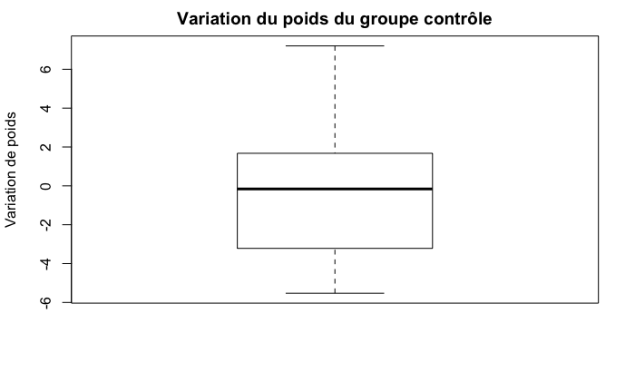

La médiane de la variation du poids pour le groupe contrôle est très proche de $0$ : cela signifie que environ la moitié du groupe a perdu du poids et l’autre moitié en a gagné. Ce résultat est conforme aux attentes, puisque ce groupe n’a subit aucune thérapie. Le poids gagné ou perdu est indépendant de toute thérapie.

## 2.2 Comparaison Groupe

Comparons à présent l’impact de ces traitrements sur les patients. Observons les variations des poids des patients durant l’étude :

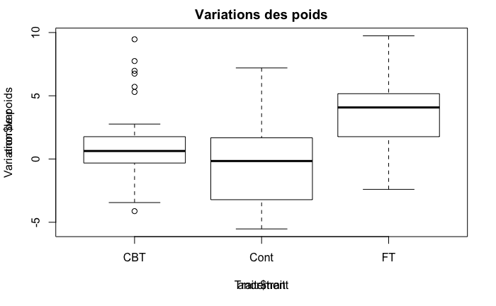

# 3 Modélisation des variables de poids

Etudions à présent la distribution des différentes variables liées au poids.

Groupe FT : Seuls la variables de poids initial et de variation ont un histogramme et un qq-plot qui indiqueraient une ressemblance avec une loi normale.

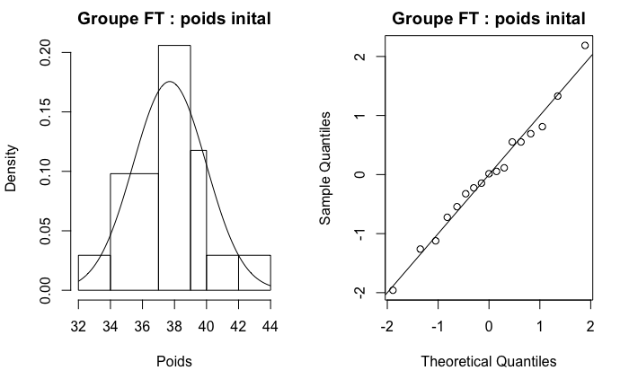

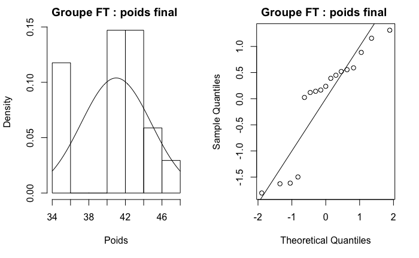

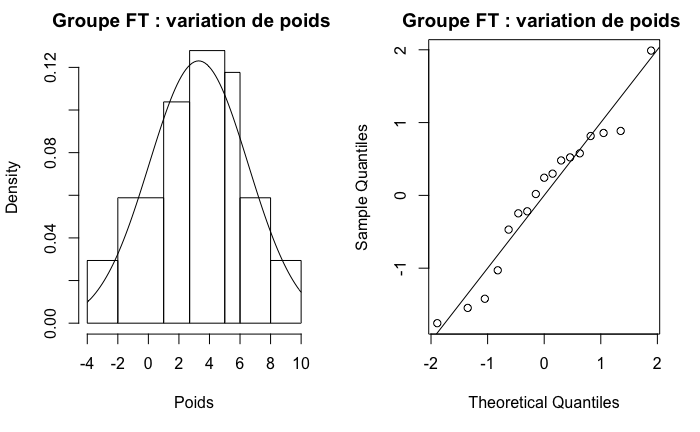

Groupe CBT : aucune des variables de poids n’est modélisable par une loi normale. En particulier pour le poids initial, bien que l’histogramme semble avoir les mêmes tendances, la crête est bien plus élevée que celle de la loi normale. De plus, on peut voir sur le qq-plot que sur une plage de x, les point sont encore aligné, mais pas sur la première bissectrice.

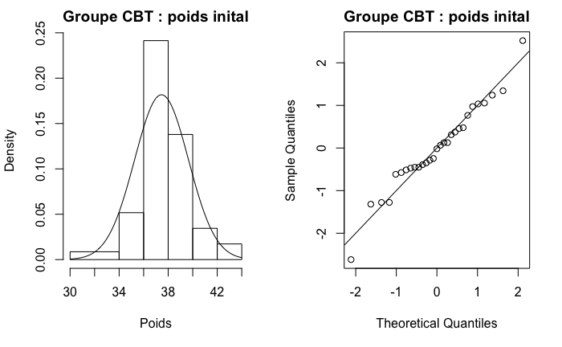

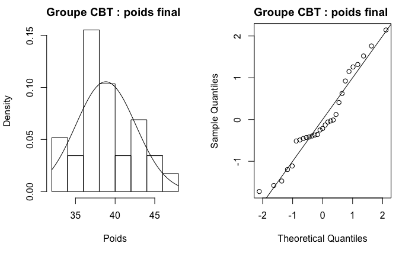

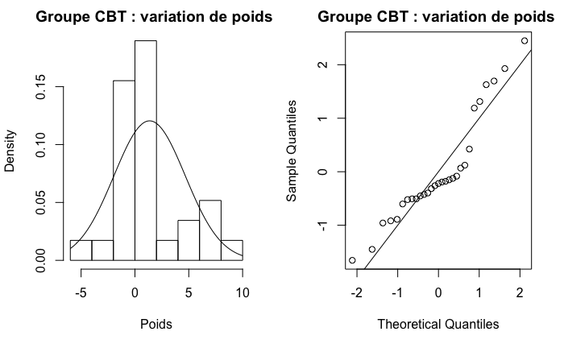

# 4 Conclusion

Le traitement FT est, selon l’échantillon fournis, le traitment le plus efficace dans le cas général et serait le traitment à recommander. Le traitement CBT ne doit cependant pas être rejeté : il faudrait étudier pour quelles catégories de patient ce traitment serait efficace afin de pouvoir le comparer au traitment FT dans ce cas particulier. Pour cette prochaine étude, l’augmentation significative de l’effectif de chaque groupe serait préférable.